# A IRT Example in Stan

## The Two-Parameter Logistic Item Response Model

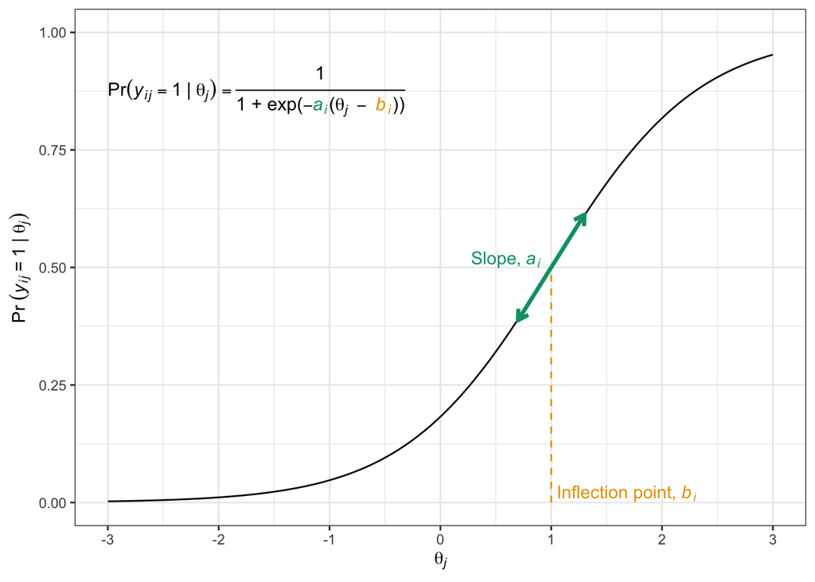

## Stan Code for 2-PL IRT Model

The Stan code for the 2-PL IRT model is below (also can be found in `stan/irt-2pl.stan`). There are four blocks of code. The `data` blocks defines the data that is sent from R to Stan. The `parameters` block defines the parameters (with any required constraints) that are to be estimated. The `model` block defines the prior distributions and the likelihood function. Finally, the `generated quantities` is used to generate new values, based on the estimated parameters.

```stan
data {
  int<lower=1> I;                            // number of items
  int<lower=1> J;                            // number of respondents
  int<lower=1> N;                            // number of observations
  int<lower=1, upper=I> ii[N];               // item of observation n
  int<lower=1, upper=J> jj[N];               // respondent of  observation n
  int<lower=0, upper=1> y[N];                // score of observation n
}
parameters {
  vector[I] b;
  vector<lower=0>[I] a;

  vector[J] theta;
}
model {
  // priors
  b ~ normal(0, 10);
  a ~ lognormal(0, 1);
  theta ~ normal(0, 1);

  y ~ bernoulli_logit(a[ii]  * (theta[jj] - b[ii]));
}
generated quantities {
  vector[N] log_lik;
  for (n in 1:N) {
    log_lik[n] = bernoulli_logit_lpmf(y[n] | a[ii[n]] * (theta[jj[n]] - b[ii[n]]));
  }
}
```

## Data

To estimate the model, we first read in the data, and put the necessary variables into a list. Note that the names of each list element correspond to the variable names in the `data` block of the Stan code.

```r
library(tidyverse)
library(here)

response_data <- read_csv(here("data", "response-data.csv"),
                          col_types = cols(resp_id = col_integer(),
                                           item_id = col_integer(),
                                           score = col_integer()))
response_data
```

| resp_id | item_id | score |
| --- | --- | --- |
| 1 | 1 | 1 |
| 1 | 2 | 1 |
| 1 | 3 | 1 |
| 1 | 4 | 1 |
| 1 | 5 | 1 |
| 1 | 6 | 0 |
| 1 | 7 | 1 |
| 1 | 8 | 1 |
| 1 | 9 | 1 |
| 1 | 10 | 0 |

[output cut: 990 more lines]

```r
num_resp <- n_distinct(response_data$resp_id)
num_item <- n_distinct(response_data$item_id)

stan_data <- list(
  I = num_item,
  J = num_resp,
  N = nrow(response_data),
  ii = response_data$item_id,
  jj = response_data$resp_id,
  y = response_data$score
)
```

We then estimate the model using the `stan()` function. We specify the location of the Stan script, the data list we created, and other characteristics of the estimation process (e.g., number of chains, iterations, etc.).

```r
irt_2pl <- stan(here("stan", "irt-2pl.stan"), data = stan_data, seed = 9416,
                chains = 4, iter = 2000, warmup = 1000, cores = 4,
                control = list(adapt_delta = 0.85, max_treedepth = 15))
```

After estimating the model, we can view the parameter estimates, and summaries of the posterior distributions.

```r
estimates <- summary(irt_2pl)$summary %>%
  as_tibble(rownames = "parameter")
estimates
```

| parameter | mean | se_mean | sd | 2.5% | 25% | 50% | 75% | 97.5% | n_eff | Rhat |
| --- | --- | --- | --- | --- | --- | --- | --- | --- | --- | --- |
| b[1] | -0.64338913582 | 0.003066455131 | 0.0647941796 | -0.7701433893 | -0.687265846082 | -0.64506395326715 | -0.59992599581216588 | -0.512792624795672002946389511635 | 446.4767 | 1.0065741 |
| b[2] | 0.90318390072 | 0.002675248956 | 0.1079781003 | 0.7013075984 | 0.829808068292 | 0.89797438944241 | 0.97482854282838616 | 1.128262772761784882291635767615 | 1629.0821 | 1.0046842 |
| b[3] | -3.33681168108 | 0.041501378317 | 1.5371454337 | -7.4972724832 | -3.874241694494 | -2.92692362105332 | -2.33471665218769475 | -1.605521723686123447549789489130 | 1371.8445 | 1.0020838 |
| b[4] | -0.60592648265 | 0.002928745239 | 0.0705715753 | -0.7418014850 | -0.653700349116 | -0.60641575529765 | -0.55917685986921040 | -0.464513012817502568552185948647 | 580.6259 | 1.0040649 |
| b[5] | 0.57328531590 | 0.010351271858 | 0.4167825804 | -0.0346198805 | 0.307902771292 | 0.51843062301554 | 0.75688133864445861 | 1.613906822953317776736525956949 | 1621.1817 | 1.0043020 |
| b[6] | 2.67857720142 | 0.011830197049 | 0.4302747344 | 2.1382903227 | 2.405766446571 | 2.59176129359450 | 2.83408967875941364 | 3.779972070598756062054235371761 | 1322.8413 | 1.0044418 |
| b[7] | -2.18675556128 | 0.007308116363 | 0.3148354399 | -2.9178030554 | -2.367083617541 | -2.14672502237767 | -1.96794802590443574 | -1.679672481423257535126936090819 | 1855.9075 | 1.0001949 |
| b[8] | -2.20290772899 | 0.048861153945 | 1.9369189466 | -7.3562706429 | -2.871369554918 | -1.73518569701812 | -1.02378946871075449 | 0.111729880317953375601369714332 | 1571.4315 | 1.0009183 |
| b[9] | -0.43447021869 | 0.002894959388 | 0.0644243661 | -0.5617405510 | -0.477358885741 | -0.43522139693279 | -0.39066473278592023 | -0.308917164643240427235326706068 | 495.2396 | 1.0050425 |
| b[10] | 0.85020384062 | 0.003415413923 | 0.1822982497 | 0.5361898029 | 0.720005355107 | 0.83777605134409 | 0.96416378684164461 | 1.237586403291420111827392247505 | 2848.9072 | 1.0001434 |

[output cut: 990 more lines]

### Convergence

Convergence is measures by the $\hat{R}$ statistic.

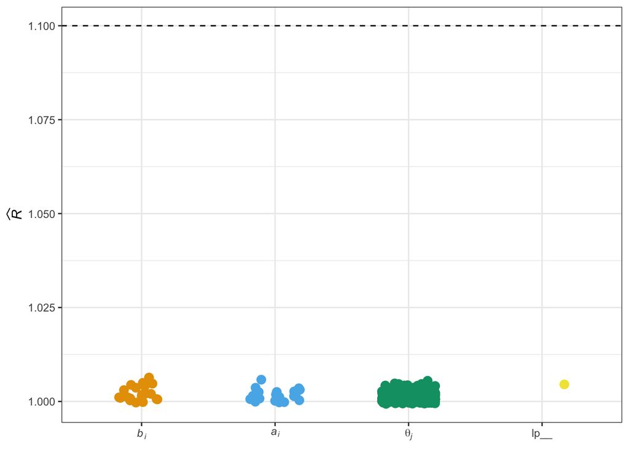

```r
sims <- as.array(irt_2pl)
apply(sims, MARGIN = 3, FUN = Rhat) %>%
  enframe(name = "parameter", value = "Rhat") %>%
  mutate(parameter = str_replace_all(parameter, "\\[.*\\]", "")) %>%
  filter(parameter %in% c("a", "b", "theta", "lp__")) %>%
  mutate(parameter = factor(parameter, levels = c("b", "a", "theta", "lp__"),
                            labels = c("italic(b[i])", "italic(a[i])",
                                       "italic(theta[j])", "lp__"))) %>%
  ggplot(aes(x = parameter, y = Rhat, color = parameter)) +
    geom_jitter(size = 3, height = 0, width = 0.2, show.legend = FALSE) +
    geom_hline(yintercept = 1.1, linetype = "dashed") +
    scale_x_discrete(labels = label_parsed) +
    labs(x = NULL, y = expression(italic(widehat(R)))) +
    scale_color_OkabeIto() +
    theme_bw()
```

### Efficiency

To evaluate the efficiency of the estimation, we can first examine the effective samples sizes. In addition the overall effective sample sizes, we can also look at more specific “bulk” and “tail” effective sample sizes. This can provide more diagnostic information about where we might see problems with our inferences.

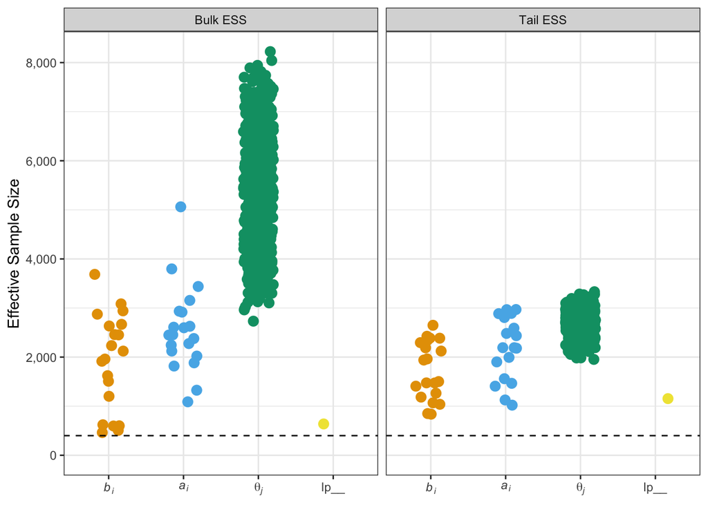

```r
bulk_ess <- apply(sims, MARGIN = 3, FUN = ess_bulk)
tail_ess <- apply(sims, MARGIN = 3, FUN = ess_tail)

ess <- list(
  summary(irt_2pl)$summary %>%
    as_tibble(rownames = "parameter") %>%
    select(parameter, n_eff),
  enframe(apply(sims, MARGIN = 3, FUN = ess_bulk), "parameter", "bulk_ess"),
  enframe(apply(sims, MARGIN = 3, FUN = ess_tail), "parameter", "tail_ess")
)

reduce(ess, full_join, by = "parameter") %>%
  mutate(parameter = str_replace_all(parameter, "\\[.*\\]", "")) %>%
  filter(parameter %in% c("b", "a", "theta", "lp__")) %>%
  mutate(parameter = factor(parameter, levels = c("b", "a", "theta", "lp__"),
                            labels = c("italic(b[i])", "italic(a[i])",
                                       "italic(theta[j])", "lp__"))) %>%
  gather(key = "measure", value = "value", -parameter) %>%
  mutate(measure = case_when(measure == "n_eff" ~ "ESS",
                             measure == "bulk_ess" ~ "Bulk ESS",
                             measure == "tail_ess" ~ "Tail ESS")) %>%
  filter(measure != "ESS") %>%
  ggplot(aes(x = parameter, y = value, color = parameter)) +
    facet_wrap(~ measure, nrow = 1) +
    geom_jitter(size = 3, height = 0, width = 0.2, show.legend = FALSE) +
    geom_hline(yintercept = 400, linetype = "dashed") +
    expand_limits(y = c(0, 4000)) +
    scale_x_discrete(labels = label_parsed) +
    scale_y_continuous(labels = scales::comma_format()) +
    scale_color_OkabeIto() +
    labs(x = NULL, y = "Effective Sample Size") +
    theme_bw()
```

We can also examine the Bayesian factor of missing information, the mean acceptance rate, and the maximum treedepth for each chain.

```r
sampler_params <- get_sampler_params(irt_2pl, inc_warmup = FALSE)
upars <- suppressMessages(stan(here("stan", "irt-2pl.stan"),
                               data = stan_data, chains = 0)) %>%
  get_num_upars()
E <- as.matrix(sapply(sampler_params, FUN = function(x) x[, "energy__"]))
EBFMI <- upars / apply(E, 2, var)
mean_accept <- sapply(sampler_params, function(x) mean(x[, "accept_stat__"]))
max_treedepth <- sapply(sampler_params, function(x) max(x[, "treedepth__"]))

tibble(chain = 1:4,
       bfmi = EBFMI,
       mean_accept = mean_accept,
       max_treedepth = as.integer(max_treedepth))
```

| chain | bfmi | mean_accept | max_treedepth |
| --- | --- | --- | --- |
| 1 | 0.6091886 | 0.9230679 | 5 |
| 2 | 0.5772133 | 0.8872000 | 5 |
| 3 | 0.7053786 | 0.9115727 | 5 |
| 4 | 0.5011990 | 0.8810798 | 5 |

### Parameter Recovery

To verify the model is defined correctly, we can look at the parameter recovery. If everything works as expected, we expect to see a strong relationship between the data-generating and estimated values.

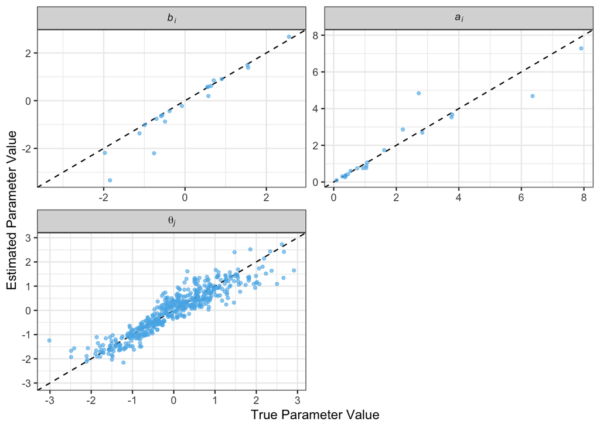

## Model Comparisons

We can compare models by using leave-one-out cross validation (LOO) and the widely applicable information criterion. We can view the LOO and WAIC for the 2-PL model by using the `loo()` and `waic()` functions.

```r
log_lik_2pl <- extract_log_lik(irt_2pl)

loo_2pl <- loo(log_lik_2pl)
waic_2pl <- waic(log_lik_2pl)

loo_2pl
```

```
Computed from 4000 by 10000 log-likelihood matrix

         Estimate   SE
elpd_loo  -4853.0 46.1
p_loo       406.0 12.6
looic      9705.9 92.2
------
Monte Carlo SE of elpd_loo is NA.

Pareto k diagnostic values:
                         Count Pct.    Min. n_eff
(-Inf, 0.5]   (good)     9351  93.5%   391
 (0.5, 0.7]   (ok)        489   4.9%   217
   (0.7, 1]   (bad)       147   1.5%   56
   (1, Inf)   (very bad)   13   0.1%   4000
See help('pareto-k-diagnostic') for details.
```

```r
waic_2pl
```

```
Computed from 4000 by 10000 log-likelihood matrix

          Estimate   SE
elpd_waic  -4829.9 45.6
p_waic       382.9 11.4
waic        9659.7 91.2
```

To compare to another model, we can estimate the 1-PL IRT model, and then compare the LOO and WAIC values.

```r
irt_1pl <- stan(here("stan", "irt-1pl.stan"), data = stan_data, seed = 9416,
                chains = 4, iter = 2000, warmup = 1000, cores = 4,
                control = list(adapt_delta = 0.85, max_treedepth = 15))
```

```r
log_lik_1pl <- extract_log_lik(irt_1pl)

loo_1pl <- loo(log_lik_1pl)
waic_1pl <- waic(log_lik_1pl)
```

When looking at the comparisons, a negative value indicates a preference for the first model listed in the comparison.

```r
compare(loo_2pl, loo_1pl)
```

```
elpd_diff        se
   -514.9      27.9
```

```r
compare(waic_2pl, waic_1pl)
```

```
elpd_diff        se
   -536.5      27.4
```